# Simple R

Session 01

I started this project to help a friend learn basic R.

The intended audience is for folks who do not have any prior coding experience.

- If you are already have coding experience (e.g. Python), I recommend Hadley’s [R for Data Science](https://r4ds.had.co.nz/)
- If you are already familiar with R, I recommend Hadley’s [Advanced R](https://adv-r.hadley.nz/)

## Installation

Download and install the two requirements:

### R

Download the pre-compiled R binary from https://cloud.r-project.org/

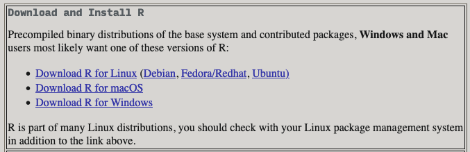

### RStudio

Download the open-source RStudio Desktop edition from [https://rstudio.com/products/rstudio/](https://www.rstudio.com/products/rstudio/)

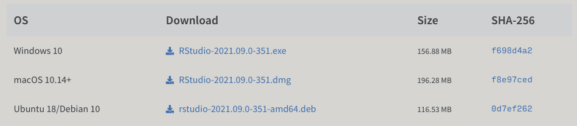

## Configuration

### Setup

Go to RStudio Preferences and under the “General” tab, uncheck the boxes highlighted in the screenshot below and select “Never” from the drop-down menu.

This will ensure that your RStudio starts cleanly each time.

[figure not shown]

### Themes

Under the “Appearance” tab, you can change the look and feel of RStudio.

[figure not shown]

Additional themes can be downloaded:

- https://github.com/lusignan/RStudio-Material-Theme
- https://github.com/max-alletsee/rstudio-themes
- Google for more

### Customize

I recommend changing the pane layout to have R Console to be on top right corner.

With this setup, you will have more room and can more easily see the output of your code as you run them.

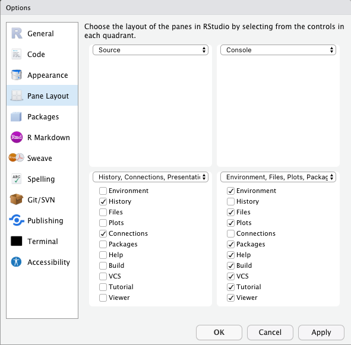

### Download Packages

There are two ways to install packages in R.

1. Run in RStudio Console:
- `install.packages(c("tidyverse", "devtools", "janitor"))`

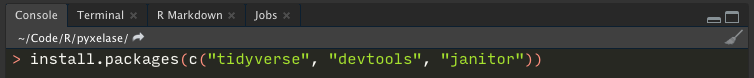

2. Navigate to the “Packages” tab and click on the “Install” button.

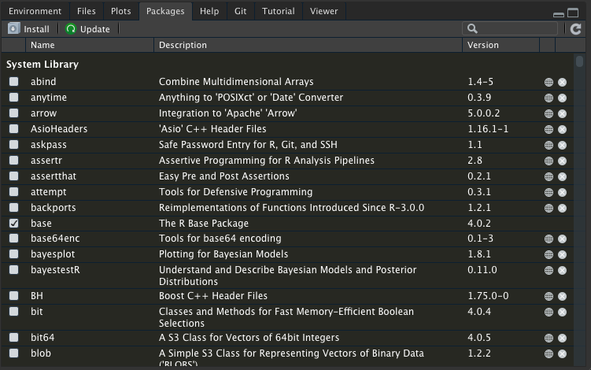

## RStudio Interface

Familiarize yourself with RStudio:

1. **Pink**: Creating new R scripts. As you can see, we have two R files open (one called “01.Rmd” and the other is “Untitled1”).
2. **Orange**: Runs the R code for the selected (highlighted) lines.
3. **Green**: R Console. The output, messages, warnings, and errors for the ran R code would appear here.
4. **Blue**: The Environment will show us the stored data we have in our session.

[figure not shown]

## End-Goal

Create a new R script (`⌘ Command` + `⇧ Shift` + `N`), then copy and paste the chunk of code you see below.

Run the script (highlight the entire code and hit `⌘ Command` + `↩︎ Enter`) to see the output in the “Viewer” panel.

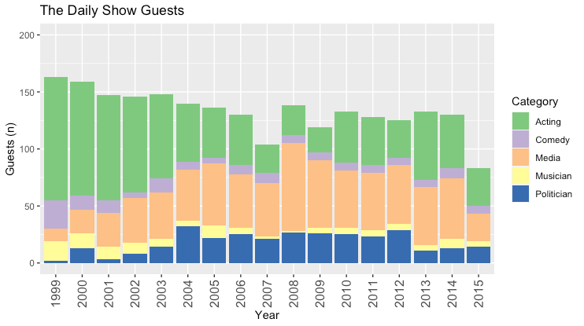

The goal of this session is to understand this code once we dive in.

```r
library(magrittr)

github_page <- "https://raw.githubusercontent.com/fivethirtyeight/data/master/daily-show-guests/"
file_name <- "daily_show_guests.csv"
url <- paste0(github_page, file_name)

daily_show_guests <- readr::read_csv(url) %>%
  janitor::clean_names()

dsg_table <- daily_show_guests %>%
  dplyr::filter(group %in% c("Acting", "Comedy", "Media", "Musician", "Politician", "Media")) %>%
  dplyr::count(year, group)

ggplot2::ggplot(
  data = dsg_table,
  mapping = ggplot2::aes(x = as.factor(year), y = n, fill = group)
) +
  ggplot2::geom_col() +
  ggplot2::labs(title = "The Daily Show Guests", x = "Year", y = "Guests (n)") +
  ggplot2::theme(
    legend.position = "right",
    axis.text.x = ggplot2::element_text(angle = 90, vjust = 0.5, hjust = 1, size = 12)
  ) +
  ggplot2::ylim(0, 200) +
  ggplot2::scale_fill_brewer(palette = "Accent") +
  ggplot2::guides(
    color = "none",
    size = "none",
    fill = ggplot2::guide_legend(title = "Category")
  )
```

This chunk of code reads a CSV file from the internet, creates a summary, then plots the data.

The input dataset (daily_show_guests.csv) looks like this:

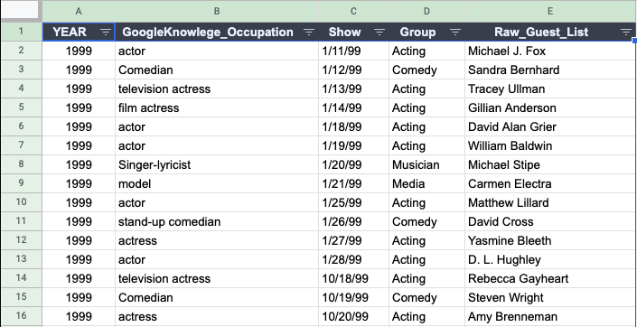

But before we can jump in, let’s learn a few terminologies.

## Terminology

- **Code**: a set of instructions
- **Function**: a named piece of code
- **Package**: a collection of functions
- **Variable**: an object that stores different types of data
- **Data Type**: such as strings, integer, and logical
- **Pipe `%>%`** : the pipe function
- **Miscellaneous**: other miscellaneous things like commenting in code

### Code

Code provides a set of instructions to the system to perform an operation.

**Cooking analogy**: a set of instructions on how to make a something.

The example below is the code to print a table.

```r
d <- dim(x)
if (any(d == 0)) {
  cat(
    "< table of extent", paste(d, collapse = " x "),
    ">\n"
  )
  return(invisible(x))
}
xx <- format(unclass(x), digits = digits, justify = justify)
if (any(ina <- is.na(x))) {
  xx[ina] <- na.print
}
if (zero.print != "0" && any(i0 <- !ina & x == 0)) {
  xx[i0] <- zero.print
}
print(xx, quote = quote, right = right, ...)
invisible(x)
```

### Function

A named piece of code that performs a specific task. Instead of repeating a chunk of code multiple times, we can give it a name and simply refer to it using that name.

For example, we assign the following title to a function called “daenerys_title”. This way, we can simply use `daenerys_title()` each time instead of repeating this whole block:

Queen Daenerys Stormborn of the House Targaryen, the First of Her Name, Queen of the Andals, the Rhoynar and the First Men, Lady of the Seven Kingdoms and Protector of the Realm, Lady of Dragonstone, Queen of Meereen, Khaleesi of the Great Grass Sea, the Unburnt, Breaker of Chains and Mother of Dragons.

A function name is followed by parenthesis: `func_name()`

- `print()`
- `save()`
- `open()`
- `write()`

**Cooking analogy**: a function is a named recipe. For example, a `pasta()` recipe.

```r
pasta()
lasagna()
pizza()
```

Using functions is advantageous:

- Avoids code repetition
- Updating code is easier
- Code is easier to read

### Package

A collection of functions. Package names are followed by two colons: `pkg_name::func_name()`

**Cooking analogy**: a package is a cookbook. For example, a `vegetarian` cookbook (package) that contains many recipes (functions).

```r
vegetarian::pizza()
vegetarian::tacos()
vegetarian::soup()
```

It is important to specify the package name when using a function.

So instead of `pizza()`, we should write `vegetarian::pizza()`. This is called “qualifying” our function.

The reason we want to do this is because multiple function names could exist from different packages.

For example:

```r
meat_lovers::pizza()
meat_lovers::tacos()
meat_lovers::soup()
```

**Cooking analogy**: qualifying a functions is like specifying from which cookbook the recipe was taken.

**Note:** When it comes to qualifying functions, there are a few exception. For example, the “base R” packages (e.g. “base”, “stats”, “utils”) that are pre-loaded when you start R do not require qualifying. For example, we would write `print()` instead of `base::print()`.

The other exception is the pipe (`%>%`) function that is discussed in the “Pipe” section.

The auto-complete helps us identify the correct function by showing the package in curly braces.

Further reading on [namespaces](https://r-pkgs.org/namespace.html#search-path)

### Parameters

Also referred to as “arguments”. Allows us to pass a piece of information as input to the function.

**Cooking analogy**: ingredients or other details. For example, the type of cheese or level of spice.

```r
vegetarian::pizza(extra_cheese = FALSE)
vegetarian::tacos(spicy_level = 5)
```

Each function will have its own set of parameters and accepted values. The documentation of the function will provide the necessary information and examples on how to use the function.

```r
temperature::convert(degrees = 50, units = "celsius")
temperature::convert(degrees = 50, units = "fahrenheit")
```

To learn how to use a function, put a question mark (`?`) in front of it and run it in Console.

For example `?rm()` or `?dplyr::if_else()`

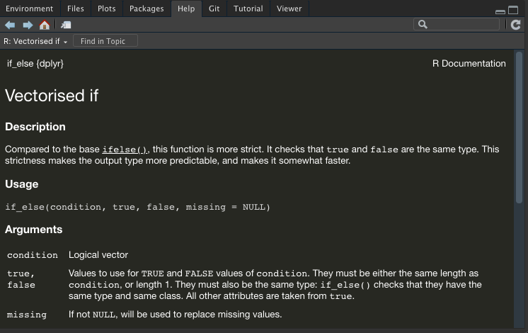

### Variable

An object that stores different types of data.

Similar to how we solve for `x` and `y` in math class.

- x = 2
- y = 3
- x + y = 5

Instead of using `=`, we use the assignment operators: `<-`

On macOS, the shortcut for this is `⌃ Control` + `-`

```r
x <- 2
y <- 3
z <- x + y

print(z)
```

```
## [1] 5
```

Further reading on [assignment operator](https://www.rdocumentation.org/packages/base/versions/3.6.2/topics/assignOps)